# Отчёт по лабораторной работе №13

Настройка NFS

Бызова Мария Олеговна

2025-11-10

# Цель работы

## Цель работы

Целью данной лабораторной работы является приобретение навыков настройки сервера NFS для удалённого доступа к ресурсам.

# Выполнение лабораторной работы

## Настройка сервера NFSv4

На сервере установим необходимое программное обеспечение (рис. 1).

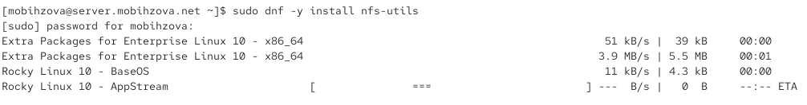

Рисунок 1: Установка пакета nfs-utils на сервере.

## Настройка сервера NFSv4

На сервере создадим каталог, который предполагается сделать доступным всем пользователям сети (корень дерева NFS) (рис. 2).

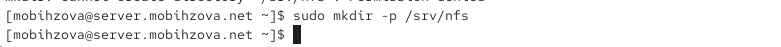

Рисунок 2: Создание корневого каталога NFS /srv/nfs.

## Настройка сервера NFSv4

В файле /etc/exports пропишем подключаемый через NFS общий каталог с доступом только на чтение (рис. 3).

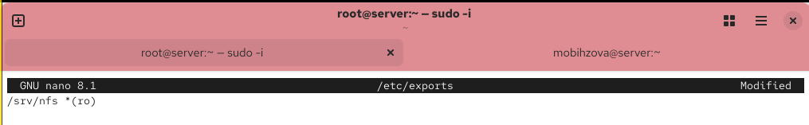

Рисунок 3: Настройка файла /etc/exports для экспорта каталога /srv/nfs.

## Настройка сервера NFSv4

Для общего каталога зададим контекст безопасности NFS и применим изменённую настройку SELinux к файловой системе (рис. 4).

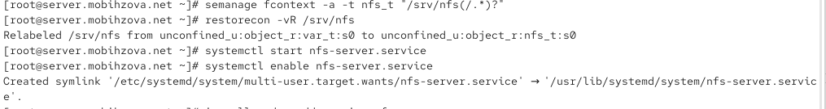

Рисунок 4: Настройка контекста безопасности SELinux для каталога /srv/nfs.

## Настройка сервера NFSv4

Настроим межсетевой экран для работы сервера NFS (рис. 5).

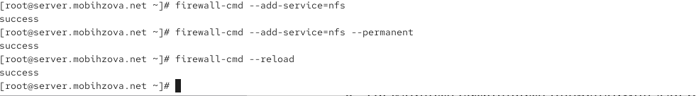

Рисунок 5: Добавление службы NFS в настройки фаервола.

## Настройка сервера NFSv4

На клиенте установим необходимое для работы NFS программное обеспечение (рис. 6).

[figure not shown]

Рисунок 6: Установка пакета nfs-utils на клиенте.

## Настройка сервера NFSv4

На клиенте попробуем посмотреть имеющиеся подмонтированные удалённые ресурсы (рис. 7).

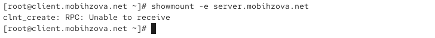

Рисунок 7: Попытка просмотра экспортируемых ресурсов до настройки фаервола.

## Настройка сервера NFSv4

Попробуем на сервере остановить сервис межсетевого экрана (рис. 8).

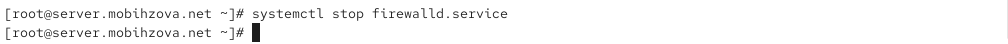

Рисунок 8: Остановка сервиса фаервола на сервере.

## Настройка сервера NFSv4

После остановки firewalld на сервере, на клиенте вновь пробуем подключиться к удалённо смонтированному ресурсу (рис. 9).

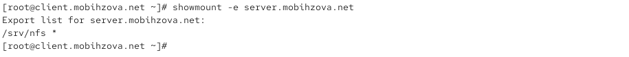

Рисунок 9: Проверка экспортируемых ресурсов после отключения фаервола.

## Настройка сервера NFSv4

На сервере запустим сервис межсетевого экрана (рис. 10).

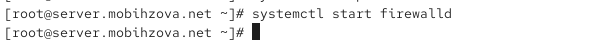

Рисунок 10: Запуск сервиса фаервола на сервере.

## Настройка сервера NFSv4

На сервере посмотрим, какие службы задействованы при удалённом монтировании (рис. 11, рис. 12).

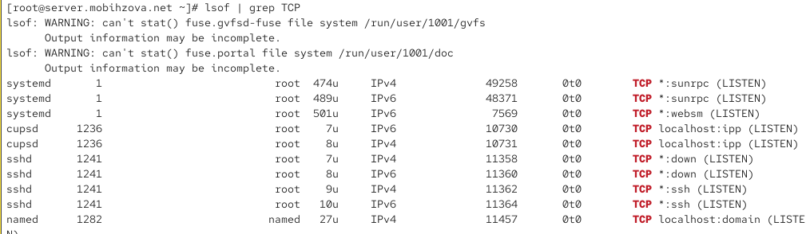

Рисунок 11: Просмотр TCP-соединений, используемых службами.

## Настройка сервера NFSv4

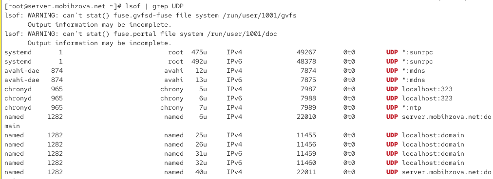

Рисунок 12: Просмотр UDP-соединений, используемых службами.

## Настройка сервера NFSv4

Добавим службы rpc-bind и mountd в настройки межсетевого экрана на сервере (рис. 13).

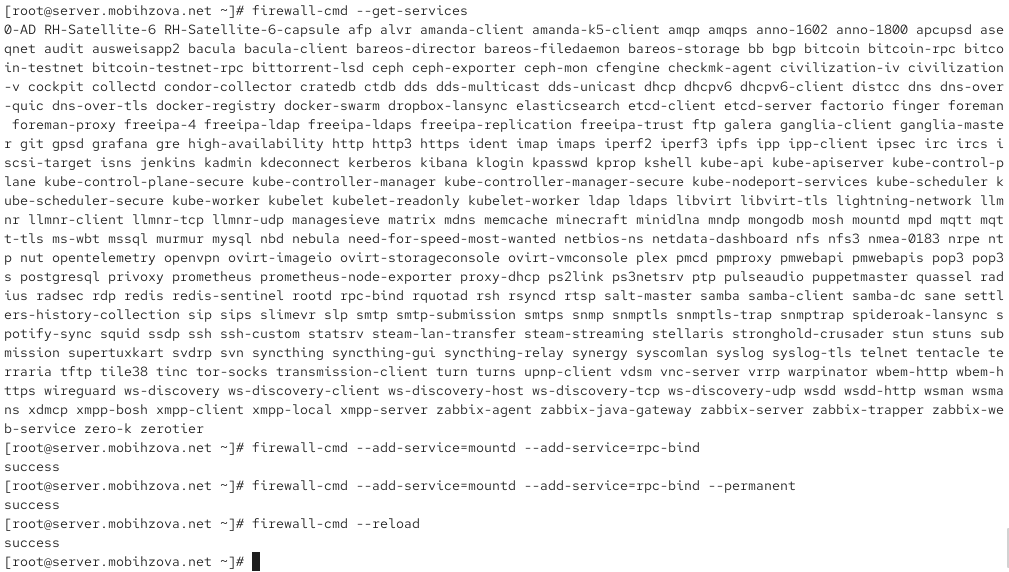

Рисунок 13: Добавление служб mountd и rpc-bind в фаервол.

## Настройка сервера NFSv4

На клиенте проверяем подключение удалённого ресурса после полной настройки фаервола (рис. 14).

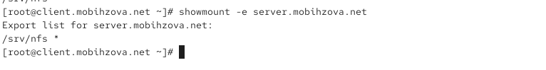

Рисунок 14: Финальная проверка экспортируемых ресурсов после настройки фаервола.

## Монтирование NFS на клиенте

На клиенте создадим каталог, в который будет монтироваться удалённый ресурс, и подмонтируем дерево NFS (рис. 15).

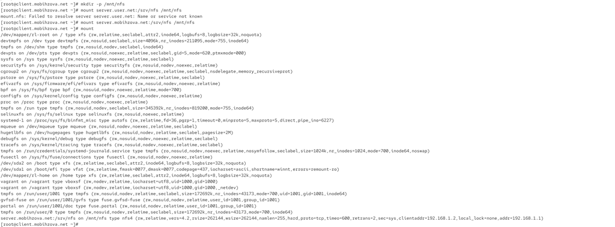

Рисунок 15: Создание точки монтирования и монтирование NFS-ресурса.

## Монтирование NFS на клиенте

На клиенте в конце файла /etc/fstab добавим запись для автоматического монтирования (рис. 16).

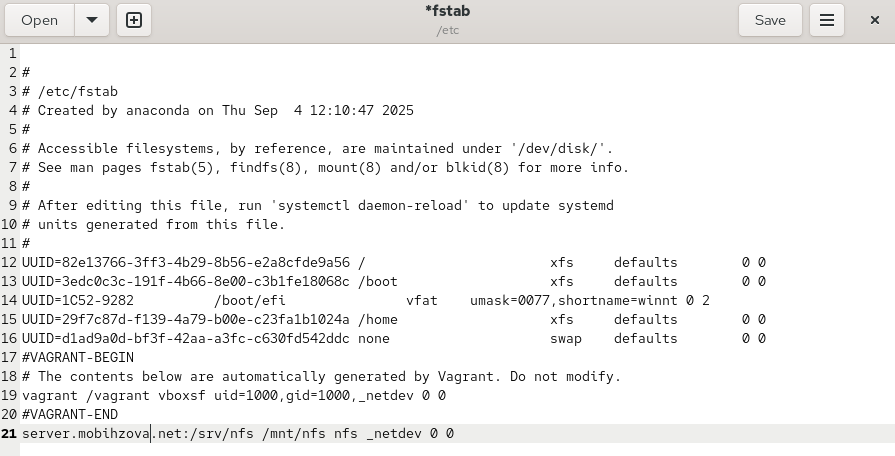

Рисунок 16: Добавление записи в /etc/fstab для автоматического монтирования.

## Монтирование NFS на клиенте

На клиенте проверим наличие автоматического монтирования удалённых ресурсов при запуске операционной системы (рис. 17).

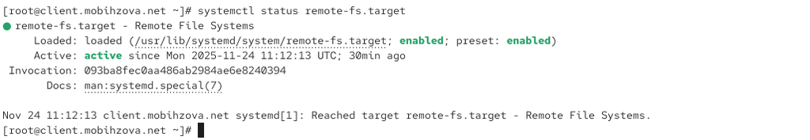

Рисунок 17: Проверка статуса сервиса remote-fs.target.

## Монтирование NFS на клиенте

На клиенте посмотрим, что отображается в каталоге /mnt/nfs (рис. 21).

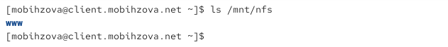

Рисунок 21: Проверка содержимого смонтированного каталога на клиенте.

## Монтирование NFS на клиенте

На сервере в файле /etc/exports добавим экспорт каталога веб-сервера (рис. 22).

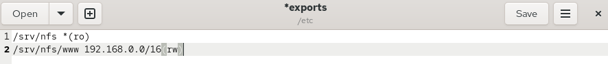

Рисунок 22: Добавление экспорта каталога /srv/nfs/www в /etc/exports.

## Монтирование NFS на клиенте

Экспортируем все каталоги, упомянутые в файле /etc/exports (рис. 23, рис. 25).

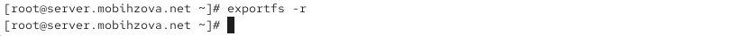

Рисунок 23: Применение изменений экспорта с помощью exportfs -r.

## Монтирование NFS на клиенте

На сервере в конце файла /etc/fstab добавим запись для автоматического bind-монтирования (рис. 24).

[figure not shown]

## Монтирование NFS на клиенте

Повторно экспортируем каталоги, указанные в файле /etc/exports (рис. 25).

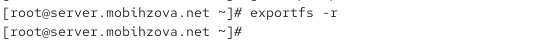

Рисунок 25: Повторное применение изменений экспорта.

## Подключение каталогов для работы пользователей

На сервере под пользователем mobihzova в его домашнем каталоге создадим каталог common с полными правами доступа только для этого пользователя (рис. 26).

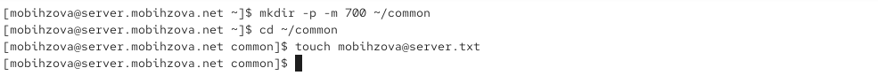

Рисунок 26: Создание пользовательского каталога common.

## Подключение каталогов для работы пользователей

Подмонтируем каталог common пользователя mobihzova в NFS (рис. 28).

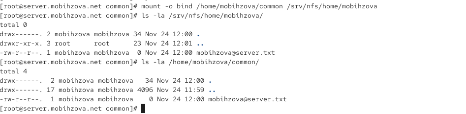

Рисунок 28: Bind-монтирование пользовательского каталога и проверка прав доступа.

## Подключение каталогов для работы пользователей

Подключим каталог пользователя в файле /etc/exports (рис. 29).

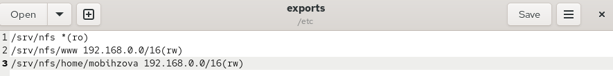

Рисунок 29: Добавление экспорта пользовательского каталога в /etc/exports.

## Подключение каталогов для работы пользователей

Внесём изменения в файл /etc/fstab для автоматического bind-монтирования (рис. 30).

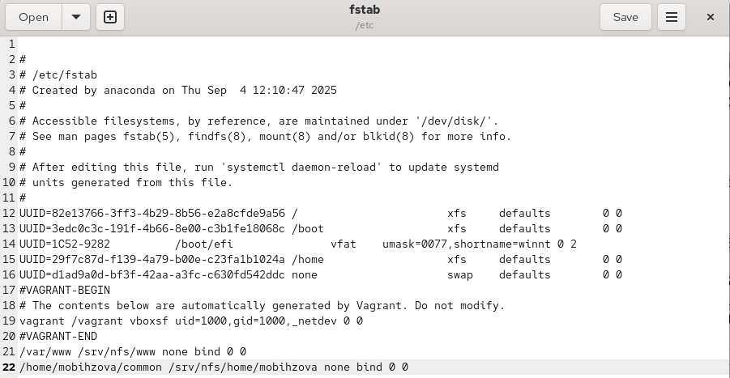

Рисунок 30: Добавление записи для пользовательского каталога в /etc/fstab сервера.

## Подключение каталогов для работы пользователей

Повторно экспортируем каталоги (рис. 31).

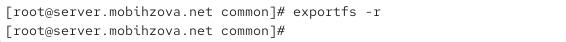

Рисунок 31: Применение изменений экспорта для пользовательского каталога.

## Подключение каталогов для работы пользователей

На клиенте проверим каталог /mnt/nfs (рис. 32).

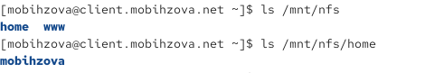

Рисунок 32: Проверка структуры каталогов на клиенте после добавления пользовательского каталога.

## Подключение каталогов для работы пользователей

На клиенте под пользователем mobihzova перейдём в каталог /mnt/nfs/home/mobihzova и попробуем создать в нём файл (рис. 33).

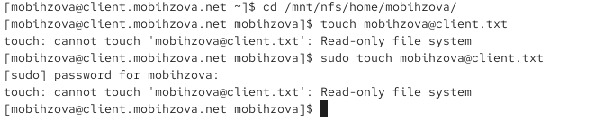

Рисунок 33: Попытка создания файла в пользовательском каталоге на клиенте.

## Подключение каталогов для работы пользователей

На сервере посмотрим, появились ли изменения в каталоге пользователя /home/mobihzova/common (рис. 34).

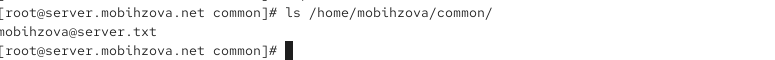

Рисунок 34: Проверка содержимого пользовательского каталога на сервере.

## Внесение изменений в настройки внутреннего окружения виртуальных машин

На виртуальной машине server перейдём в каталог для внесения изменений в настройки внутреннего окружения и создадим структуру каталогов для конфигурационных файлов (рис. 35).

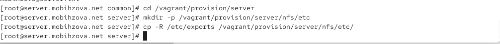

Рисунок 35: Создание структуры каталогов для provisioning на сервере.